# Incarceration Visualizations

Yukunpeng Huang

2021/2/27

## Data Description

The dataset is downloaded from the website https://github.com/vera-institute/incarceration-trends#data, there are 153811 observations, the range of years the data set covers is 1970 and 2018.

## Incarceration Trend Over Time

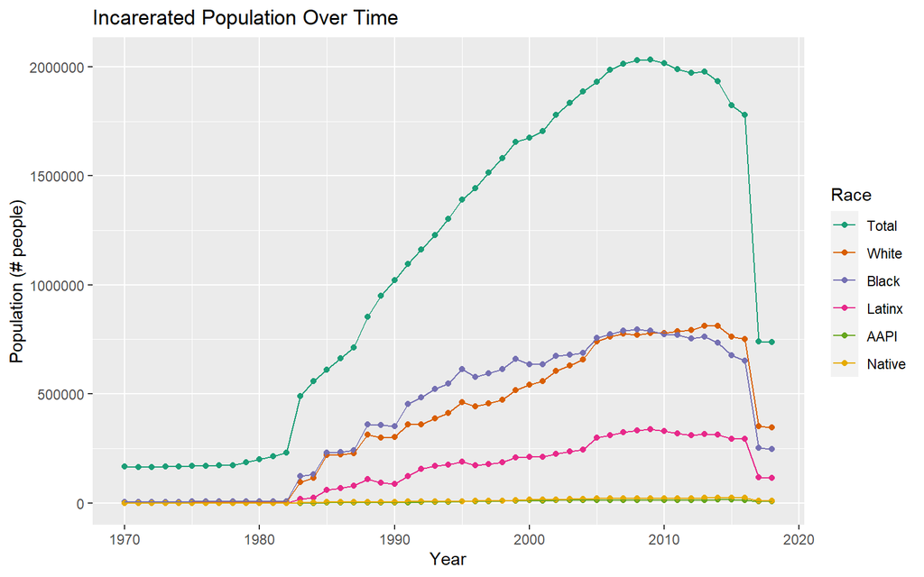

The number of incarerated people had increased from 1980, but after 2010, the population decreased, and the incarerated population of white and black have a similar trend, both are larger than other races.

## Highest Black Incarceration Rates

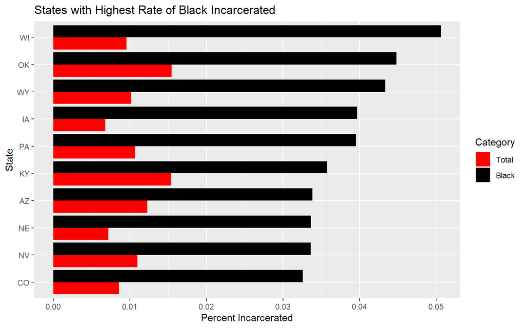

The state WI has the highest rate of black incarcerated, and the state OK has the second highest rate of black incarcerated, among all the 10 states, the rate of black incarcerated is higher than the total rate of incarcerated.

## Racial Incarceration Discrepancy Map

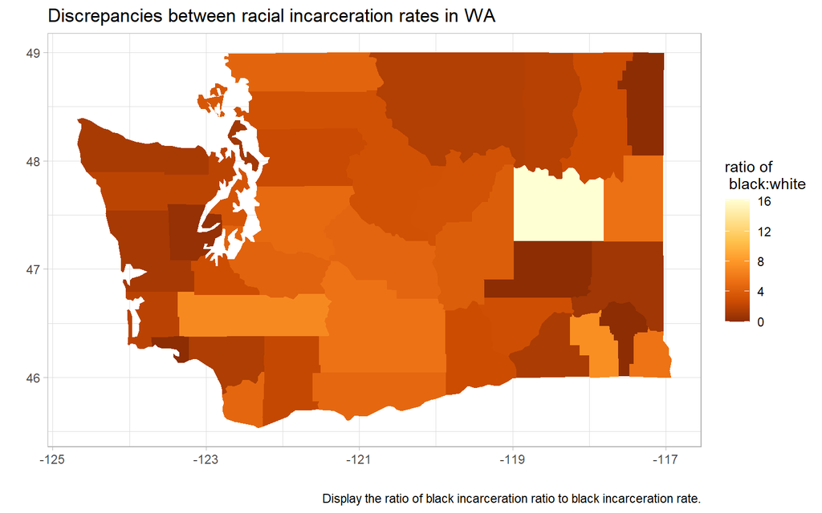

As we can see from the map, most of the county has a ratio lower than 10, Lincoln has the highest ratio of black vs white in incarceration rates in WA.

## My Own Visualization

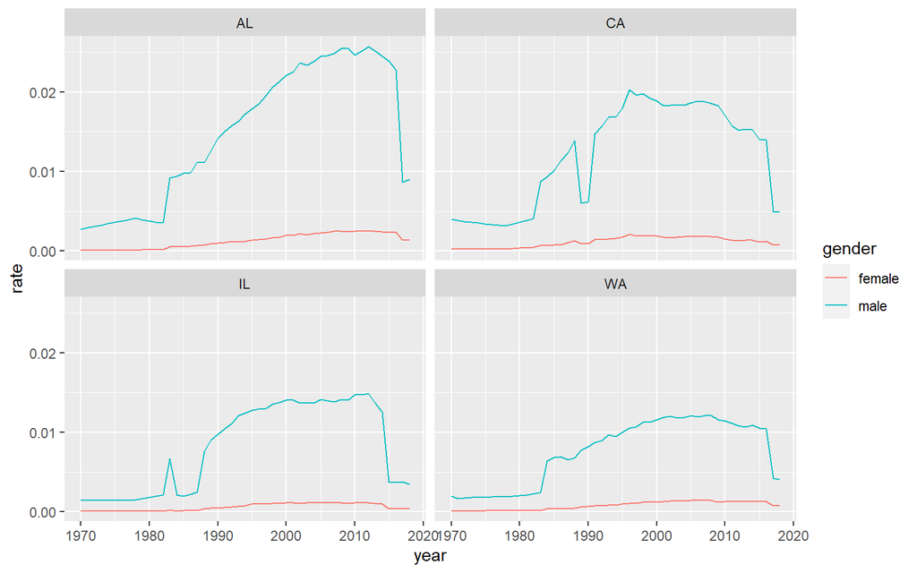

The plot suggests that female has a lower incarcerate rate than the male in the four states, and state AL has a higher incarcerate rate than the other four state.